# Paired-ABG acidemia supplement: source feasibility

Published

October 20, 2026

## Finding

**The paired-ABG acidemia analysis is unavailable for this accepted source.** Ordinary arterial PCO<sub>2</sub> and arterial pH records exist, but their same-sample linkage cannot be authenticated. Encounter/date co-occurrence is insufficient. No clinical supplemental models, paired prevalences or supplemental PIFs have been estimated. The existing clinical results and selected B/F2 figures are unchanged.

## What was checked

The narrow read-only query used the pinned accepted-source reader and original patient/encounter keys for **223,514 study-input encounters**. It retained ordinary arterial PCO<sub>2</sub> (LOINC 2019-8), arterial pH (2744-1), and selected adjusted/venous/unspecified comparator codes for audit. It did not rebuild preprocessing, change the index, select a later encounter or pair by record order. The source, input, manifest and configuration identities were stable during extraction. Event identifiers and dates remain private.

| Quantity | Records |
| --- | --- |
| Queried gas records | 541,828 |
| Ordinary arterial PCO2 records | 192,909 |
| Arterial pH records | 145,993 |
| Records with date-only precision | 541,828 |
| Populated specimen identifiers | 0 |
| Populated panel identifiers | 0 |
| Populated accession identifiers | 0 |
| Populated collection times | 0 |
| Populated result_status fields | 0 |
| Populated result_version fields | 0 |

These are record counts, not distinct blood draws or patient prevalences. The arterial analyte counts cannot be added to infer pairs. Generic `status` and `order_status` columns exist, but their correction semantics are unreviewed; the dedicated status/version counts above do not establish that all status information is absent. Unique specimens, valid pairs, unpaired measurements, ambiguous links and endpoint prevalence are **not assessable**, not zero. All supplied pairing states are source-unavailable.

## Planned analysis and unavailable positions

Two secondary positions are implemented: any valid pair with PaCO<sub>2</sub> ≥45 mm Hg, and any same pair also having pH <7.35. They retain identical patients and pairs, primary numeric spline knots, inherited adjustment and the original index. No pair means unknown, not a negative endpoint. The software retains explicit unavailable model positions without changing the existing analysis.

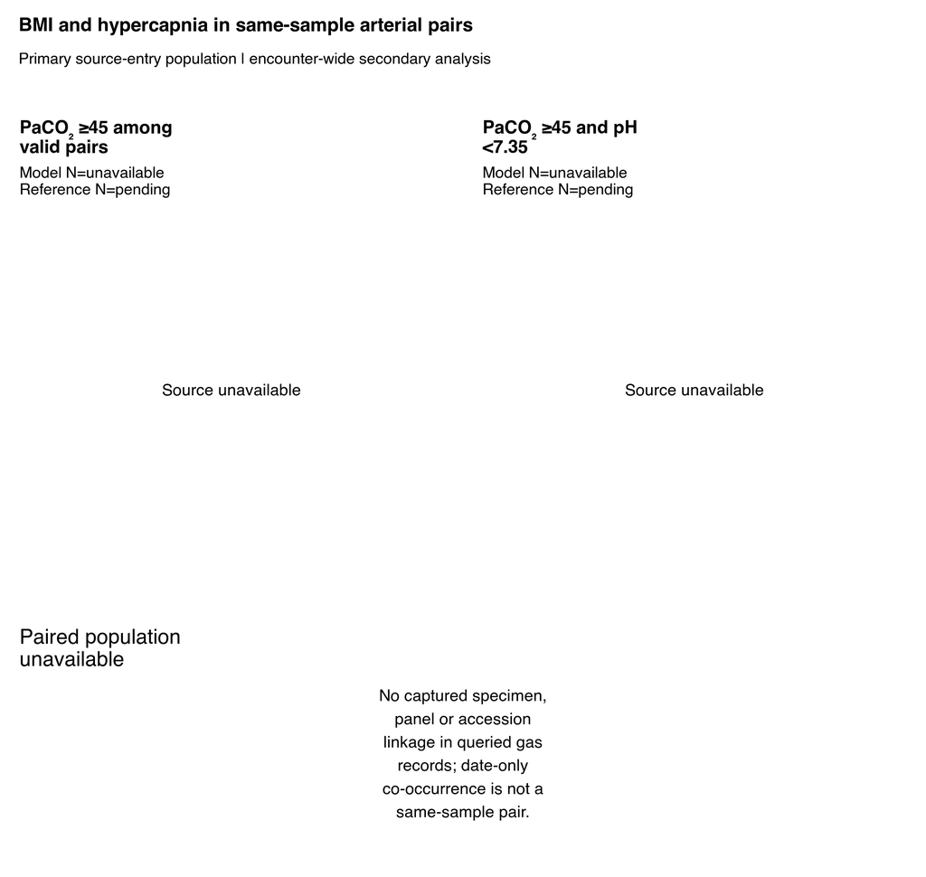

Supplement S1. Both secondary curves and the paired-population distribution are unavailable because this source cannot establish same-sample arterial PCO2 and pH. Empty positions do not indicate zero risk or zero patients. No clinical curve is drawn.

## What would permit estimation

A future source would need authenticated, source-scoped same-sample identifiers (or independently validated unique collection-time linkage), reviewed ordinary arterial pH units and validity bounds, and documented duplicate/correction rules. The inherited producer’s exclusive 6.5–7.8 pH screen was identified, but no new clinical pairing policy has been approved. This is a specific source limitation, not a request to replace the accepted dataset or permission to approximate pairs.

Even with valid pairs, acidemia would not establish acute respiratory failure; absence would not establish compensation. Treatment timing and selection into paired measurement would remain limitations. Separate fitted curves can cross and would be flagged without clipping or substituting another estimator.

## Evidence and review status

The accompanying `feasibility.json` contains source/input identity hashes and the complete aggregate counters. The private extraction and additive-enrichment receipts remain on the Mini. The original clinical snapshot remains in `results/2026-10-18/`. Software tests, numerical verification, visual inspection and investigator interpretation are distinct; this report does not grant new scientific or submission approval. No abstract has been drafted.